# Lab week 10 - Tree-based methods

Data Science and Machine Learning 2 - CEU 2018

Jeno Pal

2018-03-06

## Bagging, random forests

We covered decision trees in DS-ML-1. Using it as a base model lets us build many different models with less variance and better predictive power. The downside: interpretation gets harder.

Idea: as individual trees are unstable and have high variance, train many versions on bootstrap samples (“Bagging”: Bootstrap AGGregation). Then predict: take the average (regression), majority vote / class share (classification).

Random forests: randomly constrain the set of predictor variables used to grow trees. Goal: avoid correlated trees that are very similar to each other, still with the aim of decreasing variance.

```r
skim(data)
```

```
Skim summary statistics
 n obs: 322
 n variables: 20

Variable type: factor
  variable missing complete   n n_unique            top_counts ordered
  Division       0      322 322        2 W: 165, E: 157, NA: 0   FALSE
    League       0      322 322        2 A: 175, N: 147, NA: 0   FALSE
 NewLeague       0      322 322        2 A: 176, N: 146, NA: 0   FALSE

Variable type: integer
 variable missing complete   n    mean      sd p0    p25 median     p75  p100     hist
  Assists       0      322 322  106.91  136.85  0   7      39.5  166      492 ▇▂▁▁▁▁▁▁
    AtBat       0      322 322  380.93  153.4  16 255.25  379.5  512      687 ▁▂▇▇▆▆▇▂
   CAtBat       0      322 322 2648.68 2324.21 19 816.75 1928   3924.25 14053 ▇▃▂▂▁▁▁▁
    CHits       0      322 322  717.57  654.47  4 209     508   1059.25  4256 ▇▃▂▂▁▁▁▁
   CHmRun       0      322 322   69.49   86.27  0  14      37.5   90      548 ▇▂▁▁▁▁▁▁
     CRBI       0      322 322  330.12  333.22  0  88.75  220.5  426.25  1659 ▇▃▂▁▁▁▁▁
    CRuns       0      322 322  358.8   334.11  1 100.25  247    526.25  2165 ▇▃▂▂▁▁▁▁
   CWalks       0      322 322  260.24  267.06  0  67.25  170.5  339.25  1566 ▇▃▁▁▁▁▁▁
   Errors       0      322 322    8.04    6.37  0   3       6     11       32 ▇▆▃▂▂▁▁▁
     Hits       0      322 322  101.02   46.45  1  64      96    137      238 ▁▇▇▇▇▅▁▁
    HmRun       0      322 322   10.77    8.71  0   4       8     16       40 ▇▆▃▃▂▁▁▁
  PutOuts       0      322 322  288.94  280.7   0 109.25  212    325     1378 ▇▇▂▁▁▁▁▁
      RBI       0      322 322   48.03   26.17  0  28      44     64.75   121 ▂▇▇▆▃▃▂▁
     Runs       0      322 322   50.91   26.02  0  30.25   48     69      130 ▂▇▇▆▅▃▁▁
    Walks       0      322 322   38.74   21.64  0  22      35     53      105 ▂▇▇▅▅▂▁▁
    Years       0      322 322    7.44    4.93  1   4       6     11       24 ▆▇▅▃▃▂▁▁

Variable type: numeric
 variable missing complete   n   mean     sd   p0 p25 median p75 p100     hist
   Salary      59      263 322 535.93 451.12 67.5 190    425 750 2460 ▇▃▃▁▁▁▁▁
```

```r
data <- data[!is.na(Salary)]
data[, log_salary := log(Salary)]
data[, Salary := NULL]
```

```r
training_ratio <- 0.75
set.seed(1234)
train_indices <- createDataPartition(y = data[["log_salary"]],
                                     times = 1,
                                     p = training_ratio,
                                     list = FALSE)
data_train <- data[train_indices, ]
data_test <- data[-train_indices, ]
```

Let’s see benchmarks: a linear model and a simple regression tree.

```r
train_control <- trainControl(method = "repeatedcv",
                              number = 5,
                              repeats = 3)
set.seed(857)
linear_model <- train(log_salary ~ .,
                      method = "lm",
                      data = data_train,
                      trControl = train_control)
linear_model
```

```
Linear Regression

200 samples
 19 predictor

No pre-processing
Resampling: Cross-Validated (5 fold, repeated 3 times)
Summary of sample sizes: 160, 160, 160, 159, 161, 162, ...
Resampling results:

  RMSE       Rsquared   MAE
  0.7039273  0.4071298  0.5665639

Tuning parameter 'intercept' was held constant at a value of TRUE
```

```r
set.seed(857)
simple_tree_model <- train(log_salary ~ .,
                      method = "rpart",
                      data = data_train,
                      tuneGrid = data.frame(cp = c(0.01, 0.02, 0.05)),
                      trControl = train_control)
simple_tree_model
```

```
CART

200 samples
 19 predictor

No pre-processing
Resampling: Cross-Validated (5 fold, repeated 3 times)
Summary of sample sizes: 160, 160, 160, 159, 161, 162, ...
Resampling results across tuning parameters:

  cp    RMSE       Rsquared   MAE
  0.01  0.5553964  0.6201776  0.4124635
  0.02  0.5387555  0.6405251  0.4009572
  0.05  0.5966238  0.5666164  0.4474878

RMSE was used to select the optimal model using the smallest value.
The final value used for the model was cp = 0.02.
```

For random forests, `mtry` sets the number of variables randomly chosen for a tree. When `mtry` equals the number of features, it is the bagging.

```r
# random forest
set.seed(857)
rf_model <- train(log_salary ~ .,
                  method = "rf",
                  data = data_train,
                  trControl = train_control,
                  tuneGrid = data.frame(mtry = c(2, 3, 5, 7, 9, 12, 19)),
                  importance = T # to calculate variable importance measures
                  )
rf_model
```

```
Random Forest

200 samples
 19 predictor

No pre-processing
Resampling: Cross-Validated (5 fold, repeated 3 times)
Summary of sample sizes: 160, 160, 160, 159, 161, 162, ...
Resampling results across tuning parameters:

  mtry  RMSE       Rsquared   MAE
   2    0.4581976  0.7404439  0.3274967
   3    0.4567935  0.7395250  0.3257100
   5    0.4588722  0.7374492  0.3278753
   7    0.4618586  0.7343766  0.3309580
   9    0.4679288  0.7275473  0.3358942
  12    0.4682094  0.7273121  0.3365402
  19    0.4795420  0.7147787  0.3454379

RMSE was used to select the optimal model using the smallest value.
The final value used for the model was mtry = 3.
```

```r
# the number of trees is not a tuning parameter with caret
# default is 500, you can change it with passing the parameter to train
set.seed(857)
rf_model_ntree_10 <- train(log_salary ~ .,
                  method = "rf",
                  data = data_train,
                  trControl = train_control,
                  tuneGrid = data.frame(mtry = c(2, 3, 5)),
                  ntree = 10,
                  importance = T # to calculate variable importance measures
                  )
rf_model_ntree_10
```

```
Random Forest

200 samples
 19 predictor

No pre-processing
Resampling: Cross-Validated (5 fold, repeated 3 times)
Summary of sample sizes: 160, 160, 160, 159, 161, 162, ...
Resampling results across tuning parameters:

  mtry  RMSE       Rsquared   MAE
  2     0.4854403  0.7058451  0.3562275
  3     0.4843892  0.7117096  0.3467226
  5     0.4915282  0.6969564  0.3511114

RMSE was used to select the optimal model using the smallest value.
The final value used for the model was mtry = 3.
```

```r
# calculate test error
RMSE <- function(x, true_x) sqrt(mean((x - true_x)^2))
RMSE(data_test[["log_salary"]], predict.train(rf_model, newdata = data_test))
```

```
[1] 0.3658367
```

### Variable importance

With the ensemble models we have a hard time with interpretation. Variable importance measures can help to see which features contribute most to the predictive power of models. The generic `varImp` function of `caret` does model-specific calculations, consult [here](https://topepo.github.io/caret/variable-importance.html) for a description for your model at hand.

```r
varImp(rf_model)
```

```
rf variable importance

           Overall
CHits      100.000
CAtBat      98.638
CRuns       92.427
CRBI        89.339
CWalks      81.398
Years       76.555
CHmRun      62.081
Hits        61.772
AtBat       61.752
Walks       58.723
Runs        54.290
RBI         50.701
HmRun       27.186
PutOuts     18.721
Assists     13.758
Errors      10.504
LeagueN     10.123
NewLeagueN   5.507
DivisionW    0.000
```

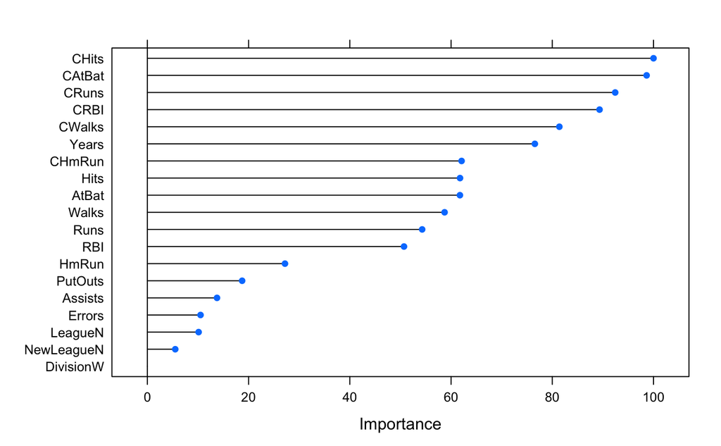

```r
plot(varImp(rf_model))
```

## Boosting - XGBoost

TBC - best algo for tabular data (not deep learning) - wins Kaggles all the time - tuning parameters: lots, requires some experimentation - stochastic tuning?

```r
gbm_grid <- expand.grid(n.trees = c(100, 300, 500),
                        interaction.depth = c(5, 10),
                        shrinkage = c(0.001, 0.01, 0.1),
                        n.minobsinnode = c(10))

gbm_model <- train(log_salary ~ .,
                   method = "gbm",
                   data = data_train,
                   trControl = train_control,
                   tuneGrid = gbm_grid,
                   verbose = FALSE # gbm by default prints too much output
                   )
gbm_model
```

```
Stochastic Gradient Boosting

200 samples
 19 predictor

No pre-processing
Resampling: Cross-Validated (5 fold, repeated 3 times)
Summary of sample sizes: 160, 159, 160, 159, 162, 161, ...
Resampling results across tuning parameters:

  shrinkage  interaction.depth  n.trees  RMSE       Rsquared   MAE
  0.001       5                 100      0.8299046  0.6941736  0.7018571
  0.001       5                 300      0.7409878  0.6968587  0.6187495
  0.001       5                 500      0.6726139  0.6996849  0.5530574
  0.001      10                 100      0.8303284  0.6895690  0.7021694
  0.001      10                 300      0.7408004  0.6961929  0.6186283
  0.001      10                 500      0.6728106  0.6986806  0.5533718
  0.010       5                 100      0.5661370  0.7046705  0.4493665
  0.010       5                 300      0.4752864  0.7125151  0.3403360
  0.010       5                 500      0.4714799  0.7133157  0.3353130
  0.010      10                 100      0.5661134  0.7027828  0.4486672
  0.010      10                 300      0.4752283  0.7110375  0.3392535
  0.010      10                 500      0.4715109  0.7115784  0.3337026
  0.100       5                 100      0.4778530  0.7077310  0.3408425
  0.100       5                 300      0.4962771  0.6899951  0.3573962
  0.100       5                 500      0.5058531  0.6808043  0.3644480
  0.100      10                 100      0.4972948  0.6823056  0.3612987
  0.100      10                 300      0.5232263  0.6580934  0.3832126
  0.100      10                 500      0.5349437  0.6465688  0.3918014

Tuning parameter 'n.minobsinnode' was held constant at a value of 10
RMSE was used to select the optimal model using the smallest value.
The final values used for the model were n.trees = 500, interaction.depth = 5, shrinkage
 = 0.01 and n.minobsinnode = 10.
```

4 hyperparameters: [the curse of dimensionality](https://en.wikipedia.org/wiki/Curse_of_dimensionality) can make it hard to come up with efficient grids for hyperparameter search. However, with `gbm` and many other models, in reality the models to be estimated are not exponentially growing with the number of hyperparameters (see [here](https://topepo.github.io/caret/random-hyperparameter-search.html)).

### XGBoost

A celebrated implementation of the gradient boosting idea. See documentation [here](http://xgboost.readthedocs.io/). It proved to be very stable and widely applicable.

```r
xgbGrid <- expand.grid(nrounds = c(100, 300, 500),
                       max_depth = c(2, 3, 5, 10),
                       eta = c(0.02, 0.05, 0.1),
                       gamma = 0,
                       colsample_bytree = c(0.5, 0.7),
                       min_child_weight = 1,
                       subsample = 1)
set.seed(857)
xgboost_model <- train(log_salary ~ .,
                       method = "xgbTree",
                       data = data_train,
                       trControl = train_control,
                       tuneGrid = xgbGrid)
xgboost_model
```

```
eXtreme Gradient Boosting

200 samples
 19 predictor

No pre-processing
Resampling: Cross-Validated (5 fold, repeated 3 times)
Summary of sample sizes: 160, 160, 160, 159, 161, 162, ...
Resampling results across tuning parameters:

  eta   max_depth  colsample_bytree  nrounds  RMSE       Rsquared   MAE
  0.02   2         0.5               100      0.9177295  0.6883560  0.7874985
  0.02   2         0.5               300      0.4721306  0.7217364  0.3423366
  0.02   2         0.5               500      0.4751149  0.7176465  0.3438754
  0.02   2         0.7               100      0.9239291  0.6788945  0.7914336
  0.02   2         0.7               300      0.4761423  0.7187765  0.3481886
  0.02   2         0.7               500      0.4740726  0.7202867  0.3461094
  0.02   3         0.5               100      0.9294369  0.6836092  0.8036496
  0.02   3         0.5               300      0.4739768  0.7203548  0.3433647
  0.02   3         0.5               500      0.4733123  0.7213890  0.3432394
  0.02   3         0.7               100      0.9339103  0.6788251  0.8056483
  0.02   3         0.7               300      0.4743613  0.7207729  0.3430581
  0.02   3         0.7               500      0.4742114  0.7205471  0.3431719
  0.02   5         0.5               100      0.9313193  0.6871545  0.8084622
  0.02   5         0.5               300      0.4749085  0.7208733  0.3439102
  0.02   5         0.5               500      0.4755175  0.7186040  0.3465994
  0.02   5         0.7               100      0.9408384  0.6720492  0.8123921
  0.02   5         0.7               300      0.4900033  0.7054924  0.3514790
  0.02   5         0.7               500      0.4891455  0.7050733  0.3521878
  0.02  10         0.5               100      0.9327219  0.6872723  0.8099669
  0.02  10         0.5               300      0.4890629  0.7084748  0.3534782
  0.02  10         0.5               500      0.4866406  0.7099791  0.3512850
  0.02  10         0.7               100      0.9419102  0.6721800  0.8136428
  0.02  10         0.7               300      0.4915717  0.7054081  0.3529016
  0.02  10         0.7               500      0.4894382  0.7055056  0.3525989
  0.05   2         0.5               100      0.4746267  0.7213570  0.3452541
  0.05   2         0.5               300      0.4776682  0.7164945  0.3433060
  0.05   2         0.5               500      0.4816180  0.7128659  0.3451870
  0.05   2         0.7               100      0.4773316  0.7192048  0.3491670
  0.05   2         0.7               300      0.4738602  0.7211894  0.3457775
```

[output cut: 37 more lines]

```
  0.10  10         0.5               100      0.4904727  0.7062242  0.3535076
  0.10  10         0.5               300      0.4905223  0.7062175  0.3535841
  0.10  10         0.5               500      0.4905217  0.7062176  0.3535836
  0.10  10         0.7               100      0.4932770  0.7024015  0.3598624
  0.10  10         0.7               300      0.4933004  0.7024060  0.3599376
  0.10  10         0.7               500      0.4932996  0.7024060  0.3599372

Tuning parameter 'gamma' was held constant at a value of 0
Tuning
 parameter 'min_child_weight' was held constant at a value of 1
Tuning parameter
 'subsample' was held constant at a value of 1
RMSE was used to select the optimal model using the smallest value.
The final values used for the model were nrounds = 300, max_depth = 3, eta = 0.05, gamma =
 0, colsample_bytree = 0.5, min_child_weight = 1 and subsample = 1.
```

## H2O

- better implementation, production-grade, easy to deploy models
- some speed/accuracy comparison? Refer to Szilard’s benchmarks